# Explaining single prediction

## Why?

- to increase *trust* in important predictions
- to *understand* which factors drive the prediction
- to inspect unusual/outlier predictions
- to improve the model

## How?

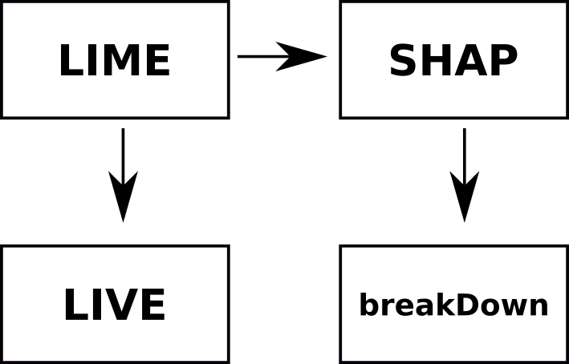

## Now details!

## LIME

## LIME: general idea

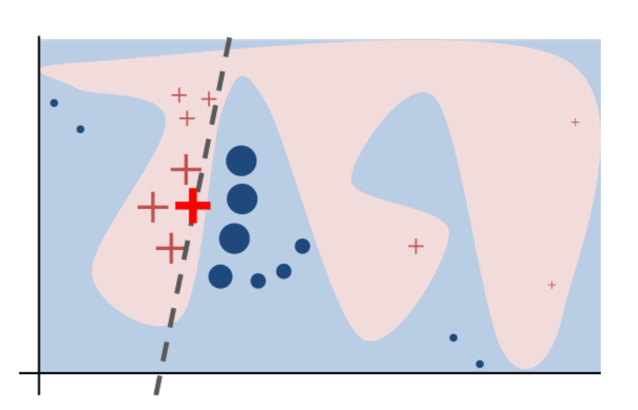

## LIME: how it's done

- Gaussian sampling for tabular, uniform sampling from interpretable inputs for image/text.
- Scores for new observation are weighted by the distance from original observation.
- Variable selection is usually based on ridge/lasso regression.
- Weights are assigned to interpretable inputs to decide if they *vote* for or against a given label.

## LIME: summary

`LIME` approximates the complex model with a simple model and discovers which features in *interpretable representation* of data drive the prediction.

Pros:

- intuitive & suitable for different types of data
- easy to understand & interpret

Cons:

- results can be inconsistent (see: Lundberg)
- depends on many *hyperparameters* (kernel, size, …)

## Shapley Values

## Shapley values: general idea

- The goal is a decomposition of prediction into sum of scores related to (simplified) features.
- The problem is solved using game theory: *Shapley values*.
- This approach unifies several methods (including `LIME`).

## Shapley values: how it's done

- Different approximate algorithms were proposed.
- Exact methods exist for linear models and tree ensemble methods.
- Classic way: sample permutations of variables, then average contributions.
- Better way: approximation based on LIME and Shapley values for regression.

## Shapley values: summary

`Shapley values` decomposition prediction into feature contributions in a rigorous way rooted in game theory.

Pros:

- good theoretical properties
- comes with good visual diagnostic tools

Cons:

- won't produce sparse explanations
- assumes *additivity*, uses simplified inputs (exception: trees)
- computational issues

## LIVE

## LIVE: general idea

- Modification of `LIME` for tabular data and regression problems.
- Similar observation for *fake* dataset are sampled from empirical distributions.
- Variable selection is possible.
- Focused on model visualization.

## LIVE: how it's done

- All new observations are treated as similar (identity kernel & equal weights) (Because of the use of empirical distributions)
- Variables are selected by LASSO (`glmnet` package).
- All models from `mlr` are supported both as black box and white box.
- Model visualization for linear models in particular.

## LIVE: summary

`live` fits a simple model to approximate the black box locally and allows model visualization for this model.

Pros:

- flexible & focused on model visualization
- local exploration in data space (no binary inputs)

Cons:

- comes with no theoretical guarantees (though *works* at least in simple cases and is pretty stable)
- inherits strengts/weaknesses of white box model

## breakDown

## breakDown: general idea

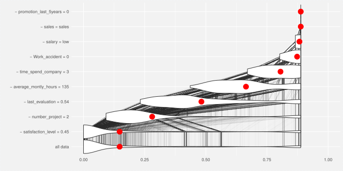

## breakDown: how it's done

- Contributions are assigned in a greedy way.
- Waterfall plots are important tool as a visual representation.

breakDown: summary

`breakDown` decompositions the prediction into feature contributions and visualizes them.

Pros:

- simple computation
- easy to interpret (in particular compared to SHAP)

Cons:

- limited to additive effects
- again, no theoretical guarantees (though can be thought of as a rough Shapley values estimate)

## Let's see some examples!

## Dataset

```r
library(DALEX)
library(live)
library(lime)
library(shapleyr)
library(mlr)
library(tidyverse)
library(e1071)
load("wine.rda")
glimpse(wine)
```

```
## Observations: 1,599
## Variables: 12
## $ fixed_acidity        <dbl> 7.4, 7.8, 7.8, 11.2, 7.4, 7.4, 7.9, 7.3, ...
## $ volatile_acidity     <dbl> 0.700, 0.880, 0.760, 0.280, 0.700, 0.660,...
## $ citric_acid          <dbl> 0.00, 0.00, 0.04, 0.56, 0.00, 0.00, 0.06,...
## $ residual_sugar       <dbl> 1.9, 2.6, 2.3, 1.9, 1.9, 1.8, 1.6, 1.2, 2...
## $ chlorides            <dbl> 0.076, 0.098, 0.092, 0.075, 0.076, 0.075,...
## $ free_sulfur_dioxide  <dbl> 11, 25, 15, 17, 11, 13, 15, 15, 9, 17, 15...
## $ total_sulfur_dioxide <dbl> 34, 67, 54, 60, 34, 40, 59, 21, 18, 102, ...
## $ density              <dbl> 0.9978, 0.9968, 0.9970, 0.9980, 0.9978, 0...
## $ pH                   <dbl> 3.51, 3.20, 3.26, 3.16, 3.51, 3.51, 3.30,...
## $ sulphates            <dbl> 0.56, 0.68, 0.65, 0.58, 0.56, 0.56, 0.46,...
## $ alcohol              <dbl> 9.4, 9.8, 9.8, 9.8, 9.4, 9.4, 9.4, 10.0, ...
## $ quality              <int> 5, 5, 5, 6, 5, 5, 5, 7, 7, 5, 5, 5, 5, 5,...
```

```r
wine_svm <- svm(quality ~., data = wine)
nobs <- 5 # wyjasniana obserwacja
```

## LIME

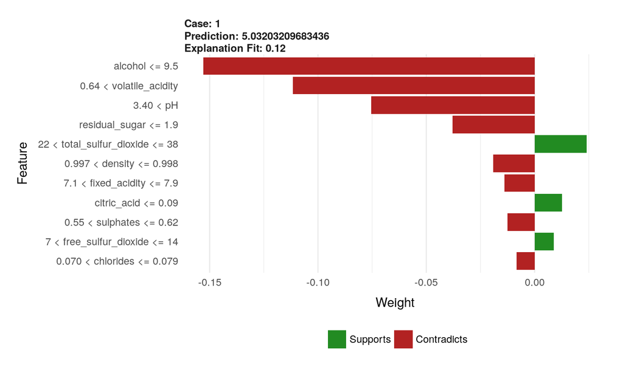

```r
lime_obj <- lime(wine, wine_svm)
model_type.svm <- function(x, ...) "regression"
lime_expl <- lime::explain(wine[nobs, ], lime_obj, n_features = 11)
plot_features(lime_expl)
```

## Shapley values

```r
tsk <- makeRegrTask(data = wine, target = "quality")
model <- train("regr.svm", tsk)
shap_expl <- shapley(nobs, model = model, task = tsk)
gather(shap_expl, "variable", "contribution") %>%
  arrange(desc(abs(contribution)))
```

```
##                variable contribution
## 1               alcohol       -0.228
## 2      volatile_acidity       -0.200
## 3             sulphates       -0.139
## 4           citric_acid        0.124
## 5         fixed_acidity       -0.050
## 6   free_sulfur_dioxide        0.035
## 7               density       -0.030
## 8                    pH       -0.027
## 9             chlorides       -0.011
## 10       residual_sugar       -0.010
## 11 total_sulfur_dioxide       -0.006
```

## LIVE

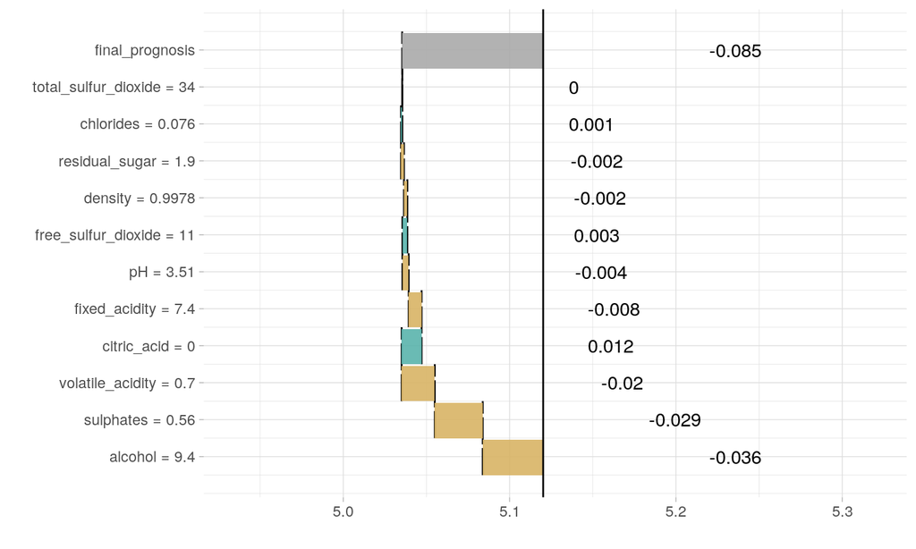

```r
local <- sample_locally(wine, wine[nobs, ], "quality", 500)
local <- live::add_predictions(wine, local, wine_svm)
live_expl <- fit_explanation(local, "regr.lm")
plot_explanation(live_expl, "waterfallplot", wine[nobs, ])
```

## LIVE cont.

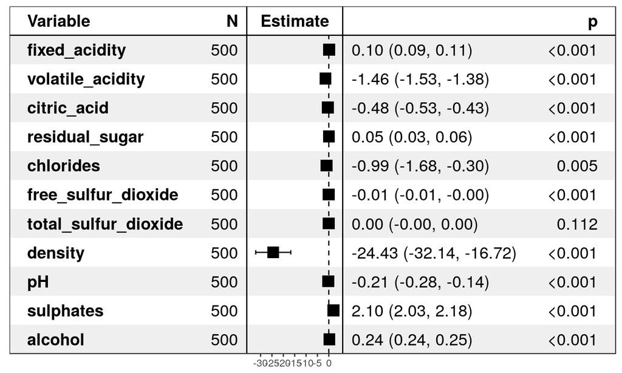

```r
plot_explanation(live_expl, "forestplot")
```

## breakDown

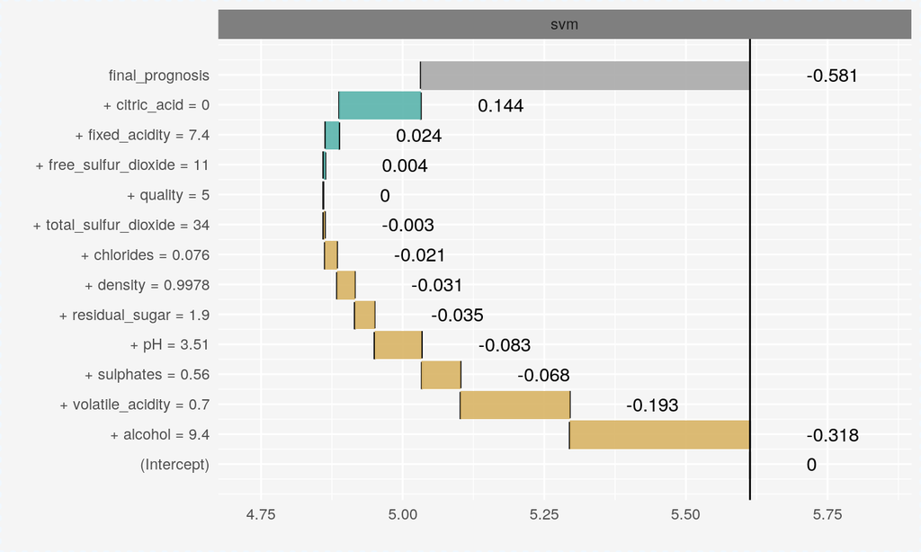

```r
wine_explainer <- DALEX::explain(wine_svm, data = wine, y = "quality")
wine_expl <- single_prediction(wine_explainer, wine[nobs, ])
plot(wine_expl)
```